# Softmax Classification from Scratch

```python
import numpy as np
import matplotlib.pyplot as plt
import pandas as pd
import time

%matplotlib inline
plt.rcParams['figure.figsize'] = (5.0, 4.0) # set default size of plots
plt.rcParams['image.interpolation'] = 'nearest'
plt.rcParams['image.cmap'] = 'gray'
```

### 0 - Read data

We use data from the Kaggle competition for digit recognition taken from MNIST. https://www.kaggle.com/c/digit-recognizer

Each image is 28 pixels in height and 28 pixels in width, for a total of 784 pixels in total. Each pixel has a single pixel-value associated with it, indicating the lightness or darkness of that pixel, with higher numbers meaning darker. This pixel-value is an integer between 0 and 255, inclusive.

```python
train = pd.read_csv("./mnist_kaggle_data/train.csv")
```

First, we view some digits to understand the data.

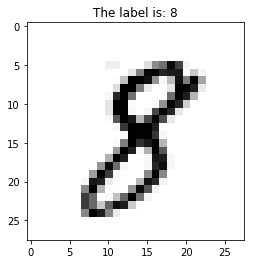

```python
def plot_digit(index):
    im = train.iloc[index, 1:]
    digit = train.iloc[index, 0]
    im_reshape = im.values.reshape(28, 28)
    plt.imshow(im_reshape, cmap='Greys')
    plt.title("The label is: " + str(digit))

plot_digit(20)
```

Next, we reshape the data such that X is a matrix with dimensions (# of features, # of training examples) and Y is a matrix with dimensions (# of Classes, # of training examples), following the setup of Andrew Ng in his deep learning course. This would involve transposing X and also one-hot encoding Y.

```python
# Take in an array with classes from 0, 1, ... n, with m number of elements
# Returns a one hot encoded matrix of shape (n, m)
def one_hot_array(Y):
    b = np.zeros((Y.size, Y.max() + 1))
    b[np.arange(Y.size), Y] = 1
    return b.T
```

```python
X = train.iloc[:, 1:].values.T
Y = train.iloc[:, 0]
Y_onehot = one_hot_array(Y.values)
print("Shape of X is: ", str(X.shape))
print("Shape of Y is: ", str(Y_onehot.shape))
```

```
Shape of X is:  (784, 42000)
Shape of Y is:  (10, 42000)
```

Next, we take a subset of the data for training and testing. We use the first 5,000 examples as training and the next 5,000 examples as testing to reduce training time, and also to prove that we don't need gigabytes of data for neural networks to work.

```python
X_train = X[:, 0:5000]
X_test = X[:, 5000:10000]
Y_train = Y_onehot[:, 0:5000]
Y_test = Y_onehot[:, 5000:10000]
print("Shape of X_train is: " + str(X_train.shape))
print("Shape of X_test is: " + str(X_test.shape))
print("Shape of Y_train is: " + str(Y_train.shape))
print("Shape of Y_test is: " + str(Y_test.shape))
```

```
Shape of X_train is: (784, 5000)
Shape of X_test is: (784, 5000)
Shape of Y_train is: (10, 5000)
Shape of Y_test is: (10, 5000)
```

### 1 - Build Helper Functions

These are functions we will use to construct the deep learning model.

```
def initialize_parameters_deep(layers_dims):
    return parameters

def L_model_forward(X, parameters):
    return AL, caches

def compute_cost(AL, Y):
    return cost

def L_model_backward(AL, Y, caches):
    return grads

def update_parameters(parameters, grads, learning_rate):
    return parameters
```

### 1a Initialise Parameters Randomly

**initialize_parameters_deep** sets up $W^{[l]}$ and $b^{[l]}$ for each hidden layer of the neural network (where $l$ denotes the $l^{th}$ hidden layer). These are the parameters the neural network will try to optimise. Note that the dimensions of the first (input) layer must correspond to the number of features in your input data, and the last (output) layer must correspond to the number of classes of Y, in this case 10.

```python
def initialize_parameters_deep(layer_dims):
    np.random.seed(3)
    parameters = {}
    L = len(layer_dims)            # number of layers in the network

    for l in range(1, L):
        parameters['W' + str(l)] = np.random.randn(layer_dims[l], layer_dims[l-1]) * 0.01
        assert(parameters['W' + str(l)].shape == (layer_dims[l], layer_dims[l-1]))

        parameters['b' + str(l)] = np.zeros((layer_dims[l], 1))
        assert(parameters['b' + str(l)].shape == (layer_dims[l], 1))

    return parameters
```

```python
parameters = initialize_parameters_deep([784, 4, 3, 2, 10])
parameters.keys()
```

```
dict_keys(['W1', 'b1', 'W2', 'b2', 'W3', 'b3', 'W4', 'b4'])
```

### 1b Forward Propagation

**softmax**, **sigmoid**, **relu** are common activation functions, which we do a simple implementation below.

```python
# For softmax, Z should be a (# of classes, m) matrix
# Recall that axis=0 is column sum, while axis=1 is row sum
def softmax(Z):
    t = np.exp(Z)
    t = t / t.sum(axis=0, keepdims=True)
    return t

def sigmoid(Z):
    A = 1 / (1 + np.exp(-Z))
    return A

def relu(Z):
    A = np.maximum(0,Z)
    assert(A.shape == Z.shape)
    return A
```

**linear_activation_forward** implements forward propagation for *one* hidden layer of the neural network. It first calculates the linear matrix multiplation Z = W.X + b, then calculates A = g(Z) where g is the non-linear activation function for that layer.

```python
def linear_activation_forward(A_prev, W, b, activation):

    if activation == "sigmoid":
        Z = np.dot(W, A_prev) + b
        A = sigmoid(Z)

    elif activation == "relu":
        Z = np.dot(W, A_prev) + b
        A = relu(Z)

    elif activation == "softmax":
        Z = np.dot(W, A_prev) + b
        A = softmax(Z)

    # Some assertions to check that shapes are right
    assert(Z.shape == (W.shape[0], A.shape[1]))
    assert (A.shape == (W.shape[0], A_prev.shape[1]))

    # Cache the necessary values for back propagation later
    cache = (A_prev, W, b, Z)

    return A, cache
```

Having defined the forward propagation for one layer, we now do a for loop through the layers with **L_model_forward**. The first L-1 layers will have the relu activation function, while the last layer will be softmax activation for a classification problem.

```python
def L_model_forward(X, parameters):

    caches = []
    A = X
    L = len(parameters) // 2                  # number of hidden layers in the neural network

    # Hidden layers 1 to L-1 will be Relu.
    for l in range(1, L):
        A_prev = A
        A, cache = linear_activation_forward(A_prev, parameters["W" + str(l)], parameters["b" + str(l)], activation="relu")
        caches.append(cache)

    # Output layer L will be softmax
    AL, cache = linear_activation_forward(A, parameters["W" + str(L)], parameters["b" + str(L)], activation="softmax")
    caches.append(cache)

    assert(AL.shape == (10, X.shape[1]))

    return AL, caches
```

```python
AL, caches = L_model_forward(X_train, parameters)
pd.DataFrame(AL[:, 0:5])
```

|  | 0 | 1 | 2 | 3 | 4 |
| --- | --- | --- | --- | --- | --- |
| 0 | 0.100001 | 0.100003 | 0.1 | 0.1 | 0.100002 |
| 1 | 0.099996 | 0.099991 | 0.1 | 0.1 | 0.099993 |
| 2 | 0.100000 | 0.100001 | 0.1 | 0.1 | 0.100001 |
| 3 | 0.100000 | 0.100000 | 0.1 | 0.1 | 0.100000 |
| 4 | 0.100000 | 0.100001 | 0.1 | 0.1 | 0.100001 |
| 5 | 0.100002 | 0.100004 | 0.1 | 0.1 | 0.100003 |
| 6 | 0.099998 | 0.099996 | 0.1 | 0.1 | 0.099997 |
| 7 | 0.099999 | 0.099997 | 0.1 | 0.1 | 0.099998 |
| 8 | 0.100001 | 0.100002 | 0.1 | 0.1 | 0.100001 |
| 9 | 0.100003 | 0.100006 | 0.1 | 0.1 | 0.100004 |

### 1c Compute Cost

We can now compute the cost $J$ after a pass of the forward propagation. Tracking the cost over each epoch (one iteration of forward/backward propagation) tells us the progress of model performance and whether it is decreasing. The cost for softmax activation is as follows (summing over all the n classes of Y and all the m examples): $$ J = -\frac{1}{m} \sum_{i=1}^m \sum_{j=1}^n y \log a^{[L]} $$

```python
def compute_cost(AL, Y):
    m = Y.shape[1]

    cost = -1/m * np.sum(np.multiply(Y, np.log(AL)))
    cost = np.squeeze(cost)      # To coerce data from [[17]] into 17
    assert(cost.shape == ())

    return cost
```

```python
compute_cost(AL, Y_train) # initial cost of 2.3
```

```
2.3025835110832511
```

### 1d Backward Propagation

Assuming that we have $dZ$, **linear_backward** calculates $dW$, $db$ and $dA\_prev$ for the backward pass.

```python
def linear_backward(dZ, A_prev, W, b):
    m = A_prev.shape[1]

    dW = 1/m * np.dot(dZ, A_prev.T)
    db = 1/m * np.sum(dZ, axis=1, keepdims=True)
    dA_prev = np.dot(W.T, dZ)

    assert (dA_prev.shape == A_prev.shape)
    assert (dW.shape == W.shape)
    assert (db.shape == b.shape)

    return dA_prev, dW, db
```

**relu_backward** and **softmax_backward** computes the backward propagation for a single unit. It takes input *dA*, *cache*, and outputs *dA_prev*, *dW* and *db*:

- For relu: $$if \text{ } Z>0: \frac{dA}{dZ} = 1\text{, ie } dZ = dA $$ $$if \text{ } Z \leqslant 0: \frac{dA}{dZ} = 0\text{, ie } dZ = 0 $$
- For softmax: $$ dZ = AL - Y $$

```python
def relu_backward(dA, cache):
    A_prev, W, b, Z = cache

    # Compute dZ
    dZ = np.array(dA, copy=True) # convert dz to a numpy array
    dZ[Z <= 0] = 0
    assert (dZ.shape == Z.shape)

    # Compute dA_prev, dW, db
    dA_prev, dW, db = linear_backward(dZ, A_prev, W, b)
    return dA_prev, dW, db

def softmax_backward(AL, Y, cache):
    A_prev, W, b, Z = cache

    # Compute dZ
    dZ = AL - Y

    # Compute dA_prev, dW, db
    dA_prev, dW, db = linear_backward(dZ, A_prev, W, b)
    return dA_prev, dW, db
```

**L_model_backward** iterates through every hidden layer from L-1 to 1 for the full backward propagation. It returns all the gradients (e.g. $dW$) for each layer, which will be used to update the parameters.

```python
def L_model_backward(AL, Y, caches):
    grads = {}
    L = len(caches) # the number of layers
    m = AL.shape[1]
    Y = Y.reshape(AL.shape) # after this line, Y is the same shape as AL

    # Backpropagation at layer L-1
    # The activation is softmax at layer L-1
    current_cache = caches[L-1]
    grads["dA" + str(L-1)], grads["dW" + str(L)], grads["db" + str(L)] = softmax_backward(AL, Y, current_cache)

    # Backpropagation from layers L-2 to 1
    # The activations are relu at all these layers
    for l in reversed(range(L-1)):
        current_cache = caches[l]
        dA_prev_temp, dW_temp, db_temp = relu_backward(grads["dA" + str(l+1)], current_cache)
        grads["dA" + str(l)] = dA_prev_temp
        grads["dW" + str(l + 1)] = dW_temp
        grads["db" + str(l + 1)] = db_temp

    return grads
```

```python
grads = L_model_backward(AL, Y_train, caches)
grads.keys()
```

```
dict_keys(['dA3', 'dW4', 'db4', 'dA2', 'dW3', 'db3', 'dA1', 'dW2', 'db2', 'dA0', 'dW1', 'db1'])
```

### 1e Update Parameters

With the gradients computed using backpropagation, we can now update the parameters of the model, using gradient descent:

$$ W^{[l]} = W^{[l]} - \alpha \text{ } dW^{[l]}$$ $$ b^{[l]} = b^{[l]} - \alpha \text{ } db^{[l]}$$

where $\alpha$ is the learning rate.

```python
def update_parameters(parameters, grads, learning_rate):
    L = len(parameters) // 2 # number of layers in the neural network
    for l in range(L):
        parameters["W" + str(l+1)] = parameters["W" + str(l+1)] - learning_rate * grads["dW" + str(l+1)]
        parameters["b" + str(l+1)] = parameters["b" + str(l+1)] - learning_rate * grads["db" + str(l+1)]

    return parameters
```

Inspecting the predicted probabilities after one parameter update, we can see that the parameters have changed slightly. We can keep running this repeatedly to see the parameters adjust.

```python
parameters = update_parameters(parameters, grads, learning_rate=0.0075)
AL, caches = L_model_forward(X_train, parameters)
pd.DataFrame(AL[:, 0:5])
```

|  | 0 | 1 | 2 | 3 | 4 |
| --- | --- | --- | --- | --- | --- |
| 0 | 0.100000 | 0.100002 | 0.099999 | 0.099999 | 0.100001 |
| 1 | 0.100004 | 0.100000 | 0.100009 | 0.100009 | 0.100002 |
| 2 | 0.100007 | 0.100008 | 0.100007 | 0.100007 | 0.100007 |
| 3 | 0.099997 | 0.099997 | 0.099997 | 0.099997 | 0.099997 |
| 4 | 0.099997 | 0.099997 | 0.099997 | 0.099997 | 0.099997 |
| 5 | 0.099997 | 0.099999 | 0.099995 | 0.099995 | 0.099998 |
| 6 | 0.100000 | 0.099998 | 0.100002 | 0.100002 | 0.099999 |
| 7 | 0.100000 | 0.099998 | 0.100001 | 0.100001 | 0.099999 |
| 8 | 0.099997 | 0.099998 | 0.099997 | 0.099997 | 0.099998 |
| 9 | 0.099999 | 0.100002 | 0.099997 | 0.099997 | 0.100001 |

### 2 - Put it all together

We can now combine the forward propagation, cost computation, backward propagation, and finally update parameters into a single function **L_layer_model** that will repeat these steps over and over again to update the weights using gradient descent.

```python
def L_layer_model(X, Y, layers_dims, learning_rate = 0.0075, num_iterations = 3000, print_cost=False):
    np.random.seed(1)
    costs = []

    # Step a: Initialise Parameters
    parameters = initialize_parameters_deep(layers_dims)

    # Iterative loops of gradient descent
    for i in range(0, num_iterations):

        # Step b: Forward Propagation
        AL, caches = L_model_forward(X, parameters)

        # Step c: Compute cost
        cost = compute_cost(AL, Y)

        # Step d: Backward Propagation
        grads = L_model_backward(AL, Y, caches)

        # Step e: Update parameters
        parameters = update_parameters(parameters, grads, learning_rate)

        # Print the cost every 100 training example
        if print_cost and i % 100 == 0:
            print ("Cost after iteration %i: %f" %(i, cost))
        if print_cost and i % 10 == 0:
            costs.append(cost)

    # plot the cost
    plt.plot(np.squeeze(costs))
    plt.ylabel('cost')
    plt.xlabel('iterations (per tens)')
    plt.title("Learning rate =" + str(learning_rate))
    plt.show()

    return parameters
```

We also implement a **predict** function, which takes in the parameters and predicts the labels for a test set, returning the predictions (1 or 0) and the probabilities (real values between 0-1). We then implement the **evaluate_prediction** function, which takes in our predictions and actual labels Y to return classification accuracy.

```python
def predict(X, parameters):
    # Forward propagation
    probabilities, caches = L_model_forward(X, parameters)

    # Calculate Predictions (the highest probability for a given example is coded as 1, otherwise 0)
    predictions = (probabilities == np.amax(probabilities, axis=0, keepdims=True))
    predictions = predictions.astype(float)

    return predictions, probabilities

def evaluate_prediction(predictions, Y):
    m = Y.shape[1]
    predictions_class = predictions.argmax(axis=0).reshape(1, m)
    Y_class = Y.argmax(axis=0).reshape(1, m)

    return np.sum((predictions_class == Y_class) / (m))
```

### 3 Test it out

We can now test it out, training our classifier and then predicting it on an out of sample test set.

```
Cost after iteration 0: 2.424205
Cost after iteration 100: 0.479788
Cost after iteration 200: 0.350552
Cost after iteration 300: 0.296694
Cost after iteration 400: 0.261329
```

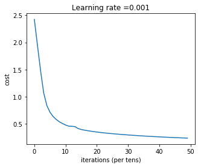

```python
layers_dims = [784, 10, 10]
parameters = L_layer_model(X_train, Y_train, layers_dims, learning_rate = 0.001, num_iterations = 500, print_cost=True)
```

```python
pred_train, probs_train = predict(X_train, parameters)
print("Train set error is: " + str(evaluate_prediction(pred_train, Y_train)))
pred_test, probs_test = predict(X_test, parameters)
print("Test set error is: " + str(evaluate_prediction(pred_test, Y_test)))
```

```
Train set error is: 0.9342
Test set error is: 0.8878
```

We see that we can achieve 89% accuracy with a fairly simple neural network! The test accuracy is lower than the train accuracy, suggesting that we are overfitting a little.  
Next, we can test our model out by submitting to Kaggle and seeing how we perform on the digit-recognizer task.

```python
test = pd.read_csv("./mnist_kaggle_data/test.csv")
X_kaggle = test.values.T
predictions, probabilities = predict(X_kaggle, parameters)
kaggle_submission = pd.DataFrame({"Label" : predictions.argmax(axis=0)})
kaggle_submission['ImageId'] = kaggle_submission.index + 1
kaggle_submission.to_csv("./mnist_kaggle_data/submission.csv", index=False)
```

As expected, test accuracy is 88.9% with this simple neural network (very similar to our development set error). We'll try to improve our accuracy in the next section.

### 4 Improvements

Let's make some minor adjustments:

- Use all of the training data
- Use a larger neural network
- Implement early stopping

```python
dev_index = np.random.choice(42000, size=2000, replace=False)
train_index = np.setdiff1d(np.arange(42000), dev_index)
X_train = X[:, train_index]
Y_train = Y_onehot[:, train_index]
X_dev = X[:, dev_index]
Y_dev = Y_onehot[:, dev_index]
```

```python
def L_layer_model_cv(X_train, Y_train, X_dev, Y_dev,
                     layers_dims, learning_rate = 0.0075, num_iterations = 3000, print_cost=False):
    np.random.seed(1)
    costs = {"cost_train" : [], "cost_dev" : []}
    accuracies = {"acc_train" : [], "acc_dev" : []}
    t0 = time.time()

    # Step a: Initialise Parameters
    parameters = initialize_parameters_deep(layers_dims)

    # Iterative loops of gradient descent
    for i in range(0, num_iterations):

        # Step b: Forward Propagation
        AL, caches = L_model_forward(X_train, parameters)
        AL_dev, caches_dev = L_model_forward(X_dev, parameters)

        # Step c: Compute cost and accuracies every 10 iterations
        if print_cost and i % 10 == 0:
            cost = compute_cost(AL, Y_train)
            cost_dev = compute_cost(AL_dev, Y_dev)
            costs["cost_train"].append(cost)
            costs["cost_dev"].append(cost_dev)

            pred_train, prob_train = predict(X_train, parameters)
            acc_train = evaluate_prediction(pred_train, Y_train)
            pred_dev, prob_dev = predict(X_dev, parameters)
            acc_dev = evaluate_prediction(pred_dev, Y_dev)
            accuracies["acc_train"].append(acc_train)
            accuracies["acc_dev"].append(acc_dev)

        # Step d: Backward Propagation
        grads = L_model_backward(AL, Y_train, caches)

        # Step e: Update parameters
        parameters = update_parameters(parameters, grads, learning_rate)

        # Print the cost every 100 training example
        if print_cost and i % 100 == 0:
            print ("Training cost after iteration %i: %f" %(i, cost))

    # plot the train and dev accuracies
    plt.plot(np.squeeze(accuracies["acc_train"]))
    plt.plot(np.squeeze(accuracies["acc_dev"]))
    plt.ylabel('Accuracy')
    plt.xlabel('iterations (per tens)')
    plt.title("Learning rate =" + str(learning_rate))
    plt.show()

    # Print final accuracies
    pred_train, probs_train = predict(X_train, parameters)
    print("Train set error is: " + str(evaluate_prediction(pred_train, Y_train)))
    pred_dev, probs_dev = predict(X_dev, parameters)
    print("Dev set error is: " + str(evaluate_prediction(pred_dev, Y_dev)))

    t1 = time.time()
    print ("Elapsed time of: " + str((t1-t0) / 60) + " minutes.")
    return parameters
```

```
Training cost after iteration 0: 7.849568
Training cost after iteration 100: 0.206063
Training cost after iteration 200: 0.142185
Training cost after iteration 300: 0.110314
Training cost after iteration 400: 0.089986
Training cost after iteration 500: 0.075482
Training cost after iteration 600: 0.064469
Training cost after iteration 700: 0.055758
Training cost after iteration 800: 0.048709
Training cost after iteration 900: 0.042898
Training cost after iteration 1000: 0.038032
Training cost after iteration 1100: 0.033920
Training cost after iteration 1200: 0.030421
Training cost after iteration 1300: 0.027421
Training cost after iteration 1400: 0.024830
Training cost after iteration 1500: 0.022585
Training cost after iteration 1600: 0.020631
Training cost after iteration 1700: 0.018918
Training cost after iteration 1800: 0.017410
Training cost after iteration 1900: 0.016080
```

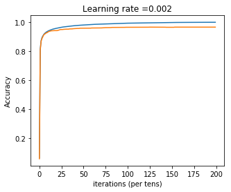

```
Train set error is: 0.998925
Dev set error is: 0.9655
Elapsed time of: 120.9637412905693 minutes.
```

```python
layers_dims = [784, 785, 10]
parameters = L_layer_model_cv(X_train, Y_train, X_dev, Y_dev,
                              layers_dims, learning_rate = 0.002, num_iterations = 2000, print_cost=True)
```

From the plot of training set accuracy vs development set accuracy, we do see a gradual divergence as we run more iterations. The interesting thing is that dev set accuracy does not drop, but seems to taper off. This suggests that we are not overfitting too much and do not need to do early stopping.

```python
test = pd.read_csv("./mnist_kaggle_data/test.csv")
X_kaggle = test.values.T
predictions, probabilities = predict(X_kaggle, parameters)
kaggle_submission = pd.DataFrame({"Label" : predictions.argmax(axis=0)})
kaggle_submission['ImageId'] = kaggle_submission.index + 1
kaggle_submission.to_csv("./mnist_kaggle_data/submission.csv", index=False)
```

After submitting this to Kaggle, and we get a 96.7% accuracy! That's pretty good!